# padmaska_m5_as4

Artsiom Padmaska

2024-01-31

```
##         Date Value
## 1 1981-01-01  20.7
## 2 1981-01-02  17.9
## 3 1981-01-03  18.8
## 4 1981-01-04  14.6
## 5 1981-01-05  15.8
## 6 1981-01-06  15.8
```

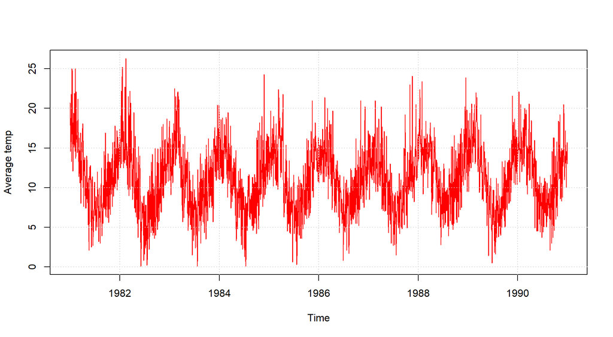

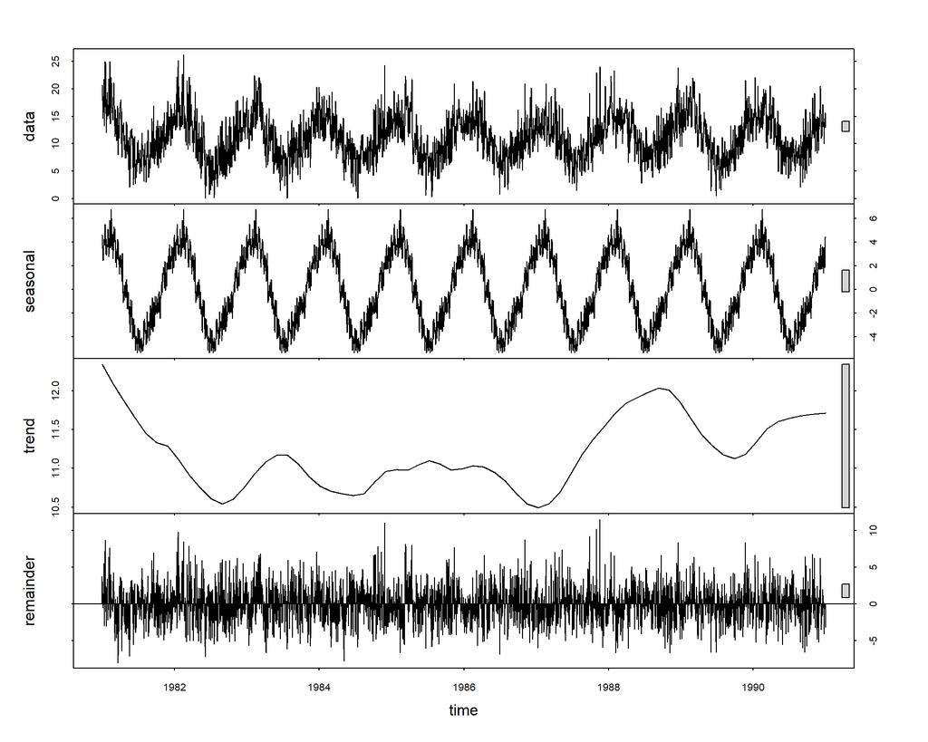

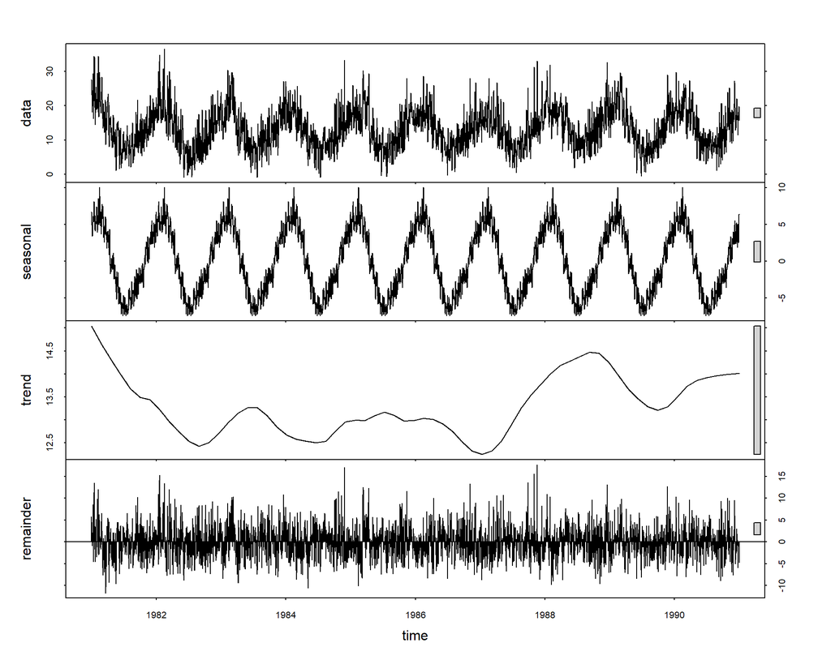

the remainder is huge for both tseries, so let’s try other datapoints (monthly average)

```
## # A tibble: 120 × 2
##    Date       Value
##    <date>     <dbl>
##  1 1981-01-01 17.7
##  2 1981-02-01 17.7
##  3 1981-03-01 13.5
##  4 1981-04-01 12.4
##  5 1981-05-01  9.49
##  6 1981-06-01  7.31
##  7 1981-07-01  7.58
##  8 1981-08-01  7.24
##  9 1981-09-01 10.1
## 10 1981-10-01 10.1
## # ℹ 110 more rows
```

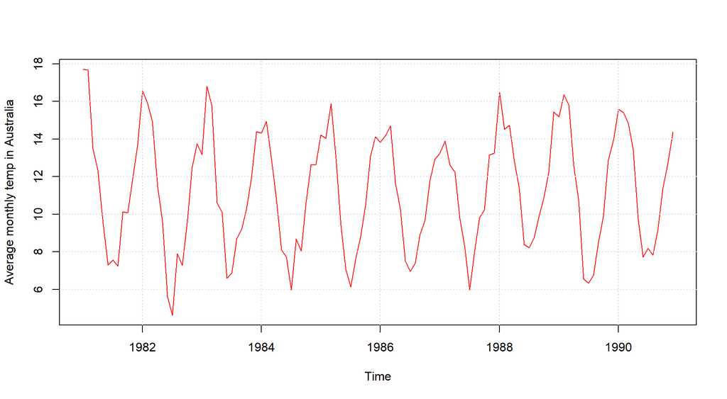

STL decomposition:

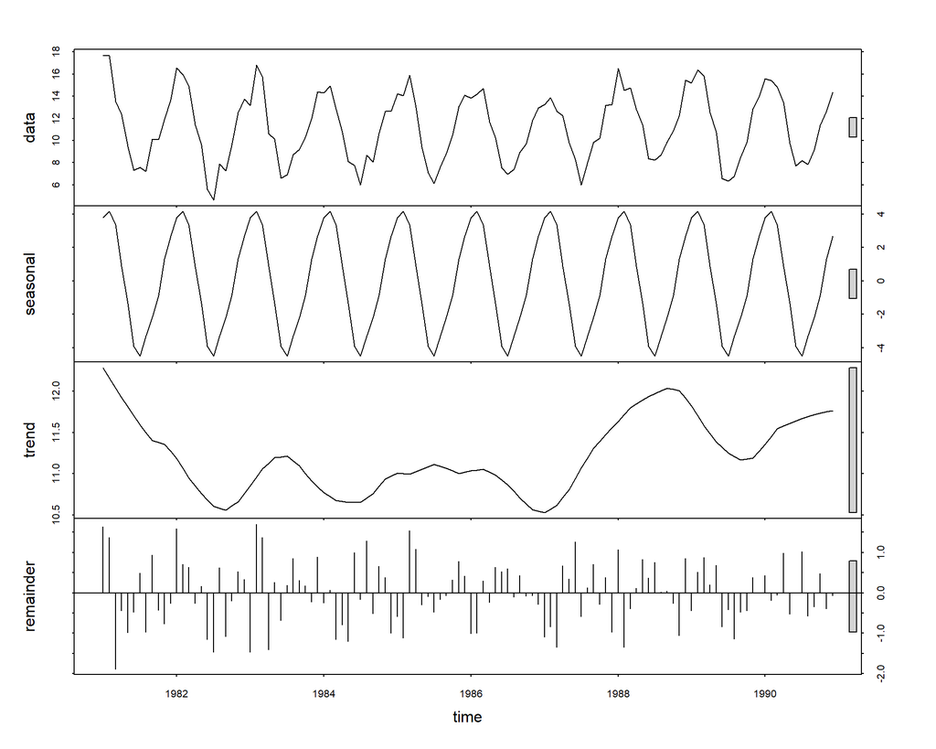

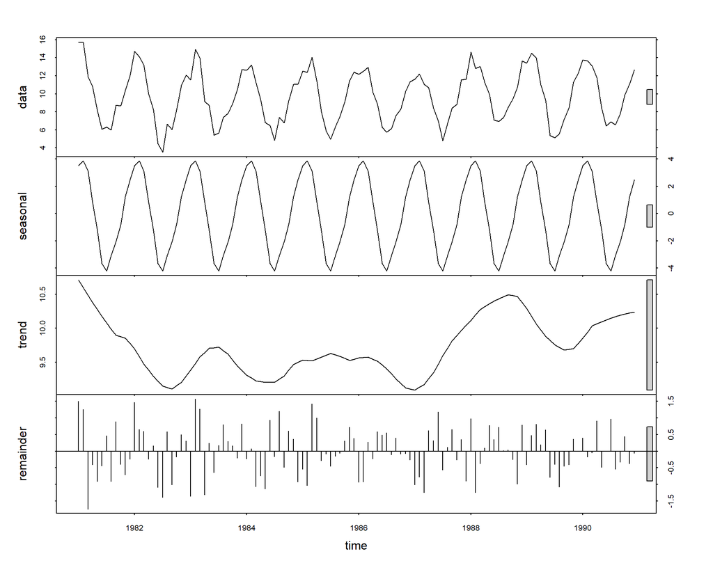

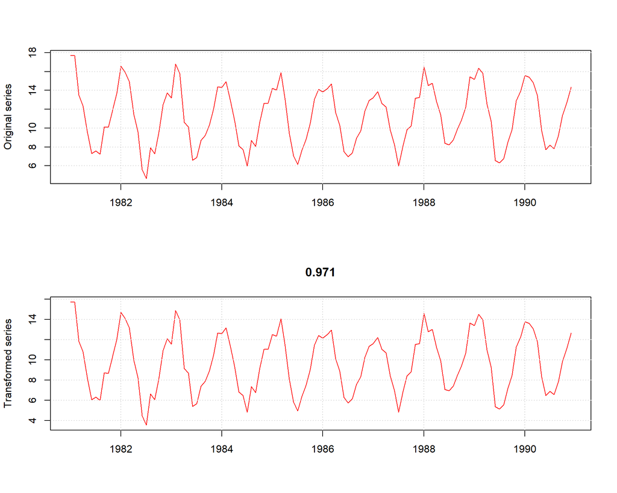

they are almost identical, but i’d prefer to use transformation

```
## Series: tSeries
## ARIMA(2,0,0)(0,1,1)[12]
## Box Cox transformation: lambda= 0.9708332
##
## Coefficients:
##          ar1     ar2    sma1
##       0.1973  0.2278  -0.793
## s.e.  0.0997  0.0986   0.150
##
## sigma^2 = 0.877:  log likelihood = -150.61
## AIC=309.21   AICc=309.6   BIC=319.94
```

ARIMA(2,0,0)(0,1,1)[12]

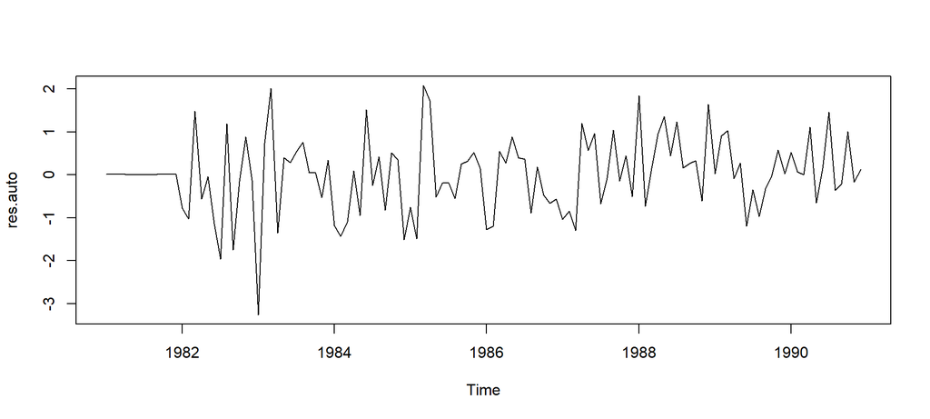

first results don’t look good, so i’d cut the first year (12)

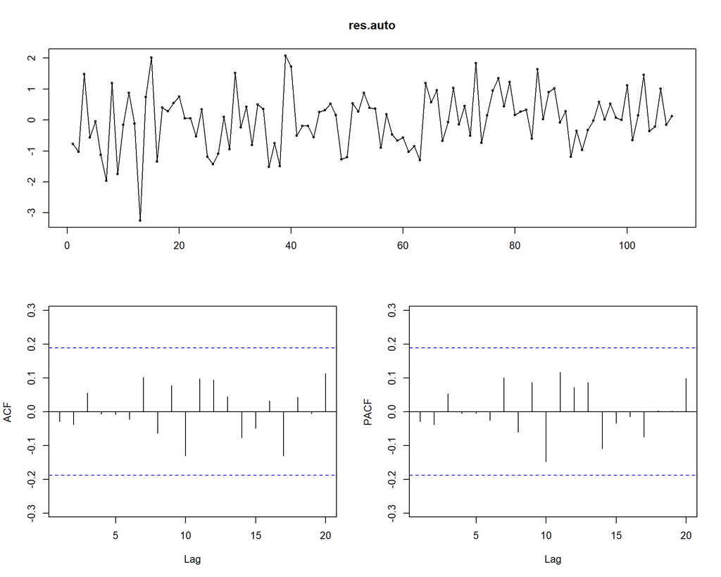

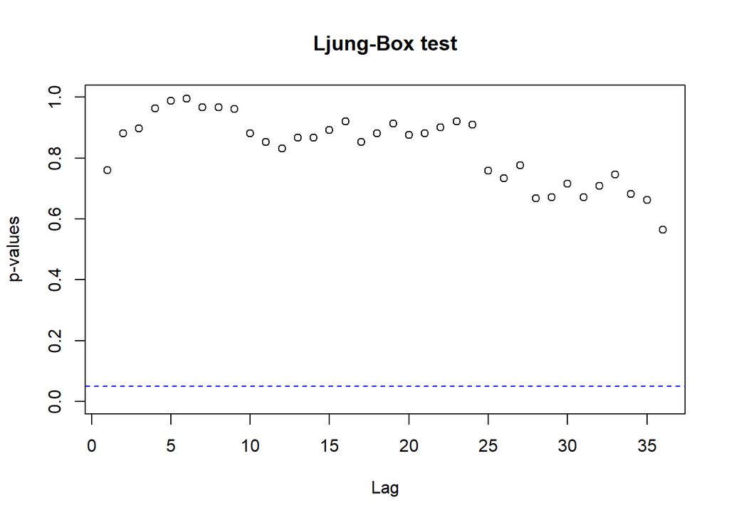

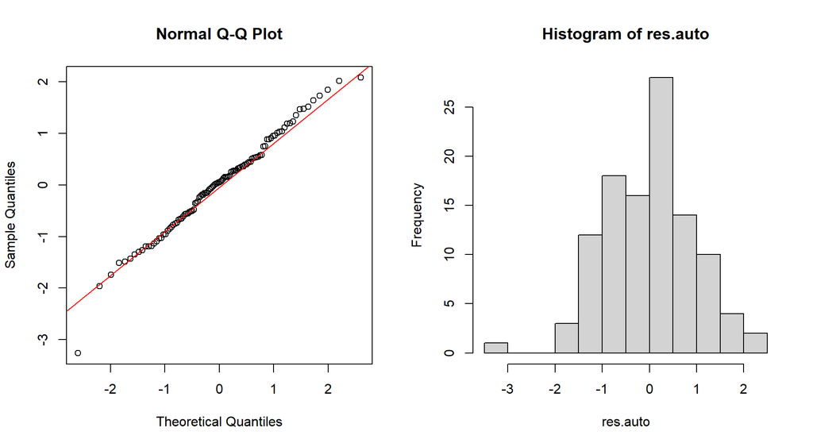

```r
shapiro.test(res.auto)$p.value
```

```
## [1] 0.4912263
```

```r
wilcox.test(res.auto)$p.value
```

```
## [1] 0.8818224
```

```r
kpss.test(res.auto)$p.value
```

```
## [1] 0.04438268
```

All hypothesis are not rejected except stationarity, but it is close to 0.05

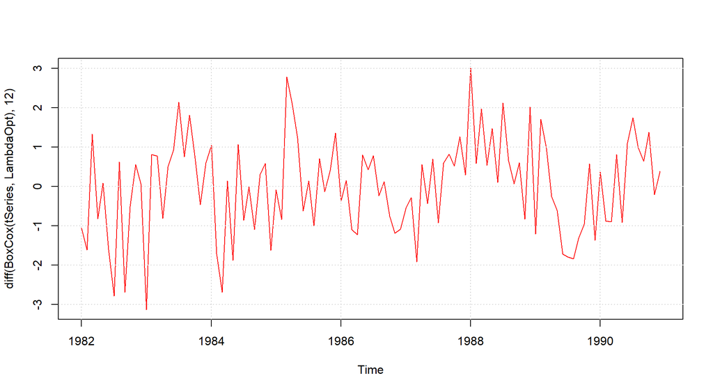

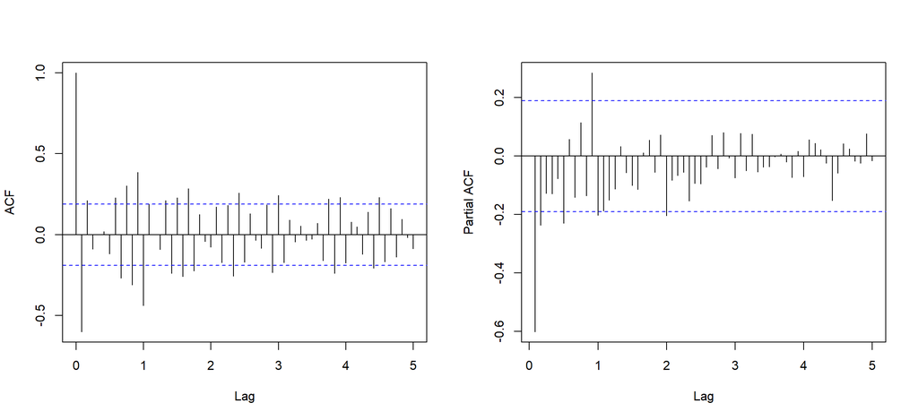

PACF: 24 is maximal significant seasonal lag, we select initial values $P=2$, $p=11$.

```
## Series: tSeries
## ARIMA(0,1,1)(0,1,1)[12]
## Box Cox transformation: lambda= 0.9708332
##
## Coefficients:
##           ma1     sma1
##       -0.7843  -0.8040
## s.e.   0.0881   0.1383
##
## sigma^2 = 0.9219:  log likelihood = -153.15
## AIC=312.3   AICc=312.53   BIC=320.31
```

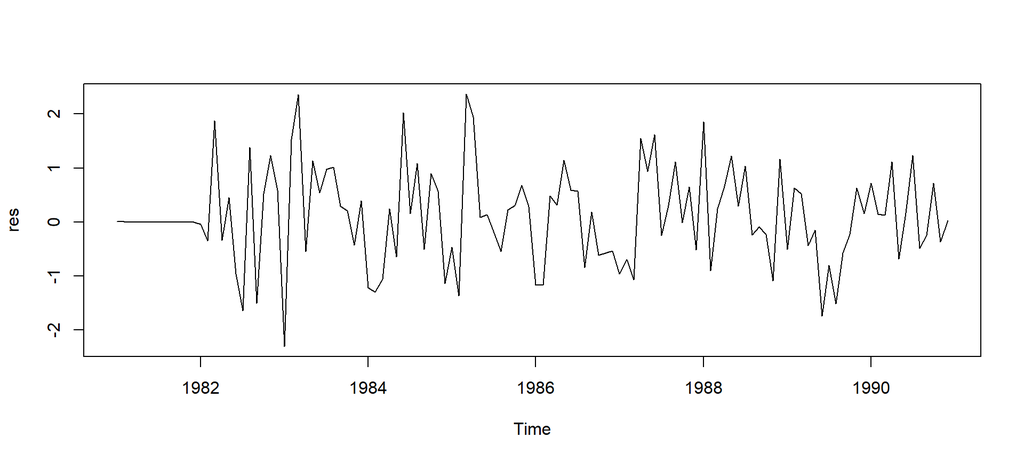

cut the first 12:

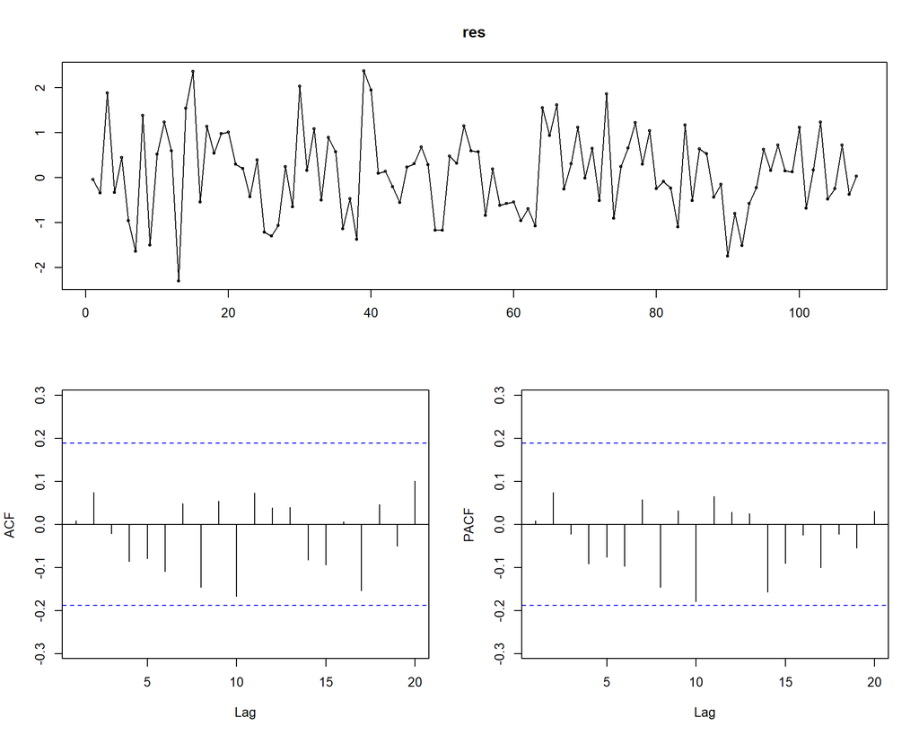

Ljung-Box test p-values for the residuals:

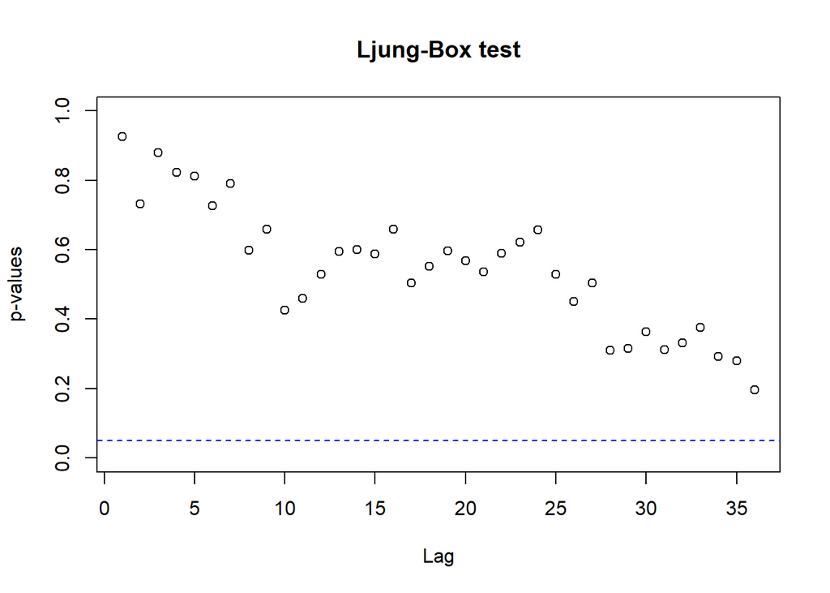

Q-Q plot and histogram of the residuals:

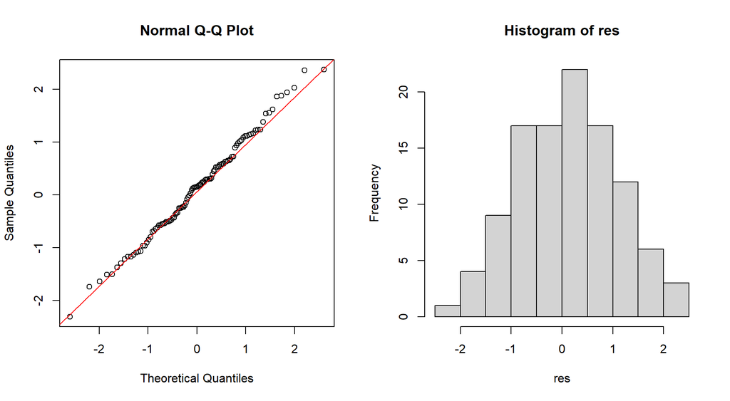

```r
shapiro.test(res)$p.value
```

```
## [1] 0.9120797
```

```r
wilcox.test(res)$p.value
```

```
## [1] 0.2652023
```

```r
kpss.test(res)$p.value
```

```
## [1] 0.1
```

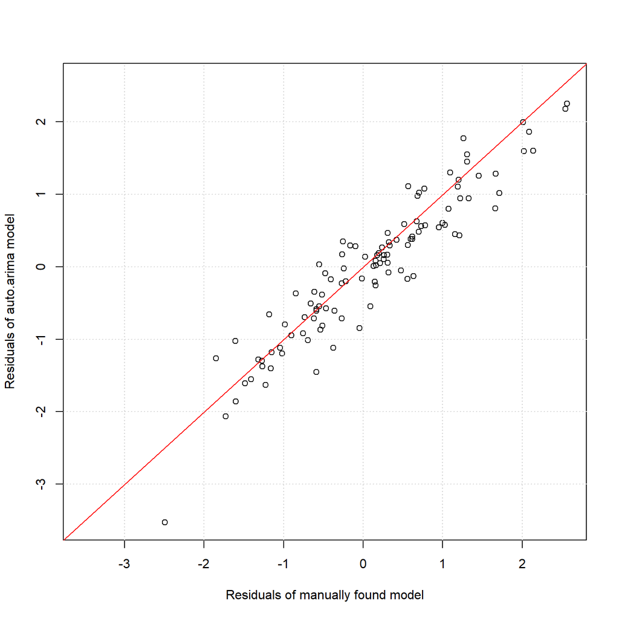

seems like auto model is quite better than manual one (based on AIC), so i’ll use auto arima. not using bootstrap, because it’s not rejected that it’s normal

```
##          Point Forecast     Lo 80     Hi 80     Lo 95     Hi 95
## Jan 1991      15.158490 13.857520 16.460738 13.170771 17.151868
## Feb 1991      15.367462 14.040930 16.695305 13.340699 17.400029
## Mar 1991      14.724759 13.355430 16.095547 12.632778 16.823200
## Apr 1991      12.451871 11.083559 13.821909 10.361877 14.549508
## May 1991      10.081198  8.717659 11.446860  7.999163 12.172640
## Jun 1991       7.441300  6.089386  8.796060  5.378297  9.516931
## Jul 1991       6.978301  5.628647  8.330985  4.919085  9.050970
## Aug 1991       7.826834  6.472329  9.184051  5.759632  9.906068
## Sep 1991       9.070849  7.710230 10.433822  6.993673 11.158459
## Oct 1991      10.473081  9.106546 11.841666  8.386344 12.568905
## Nov 1991      12.599549 11.225474 13.975344 10.500731 14.705983
## Dec 1991      14.048419 12.669903 15.428486 11.942534 16.161171
## Jan 1992      15.081918 13.674340 16.491001 12.931510 17.238990
## Feb 1992      15.279287 13.870107 16.689956 13.126403 17.438764
## Mar 1992      14.689958 13.280531 16.100935 12.536794 16.849984
## Apr 1992      12.425103 11.022450 13.829574 10.282736 14.575522
## May 1992      10.068156  8.674165 11.464370  7.939711 12.206450
## Jun 1992       7.432811  6.051557  8.817041  5.325159  9.553672
## Jul 1992       6.973756  5.595180  8.355497  4.870541  9.091029
## Aug 1992       7.824046  6.440607  9.210317  5.712795  9.947863
## Sep 1992       9.069291  7.679635 10.461403  6.947877 11.201596
## Oct 1992      10.472163  9.076471 11.869997  8.340978 12.612833
## Nov 1992      12.599035 11.195636 14.004227 10.455489 14.750528
## Dec 1992      14.048132 12.640194 15.457687 11.897356 16.206072
## Jan 1993      15.081768 13.645437 16.519667 12.887484 17.282993
## Feb 1993      15.279218 13.841317 16.718670 13.082505 17.482796
## Mar 1993      14.689939 13.251881 16.129611 12.493088 16.893936
## Apr 1993      12.425121 10.993992 13.858143 10.239324 14.619303
## May 1993      10.068203  8.645927 11.492794  7.896649 12.250014
## Jun 1993       7.432891  6.023625  8.845257  5.282609  9.596935
## Jul 1993       6.973848  5.567318  8.383675  4.828109  9.134234
## Aug 1993       7.824131  6.412634  9.238578  5.670167  9.991184
## Sep 1993       9.069366  7.651520 10.489770  6.905006 11.245069
## Oct 1993      10.472230  9.048219 11.898470  8.297879 12.656458
## Nov 1993      12.599091 11.167210 14.032840 10.412102 14.794354
## Dec 1993      14.048182 12.611666 15.486383 11.853805 16.250020
```

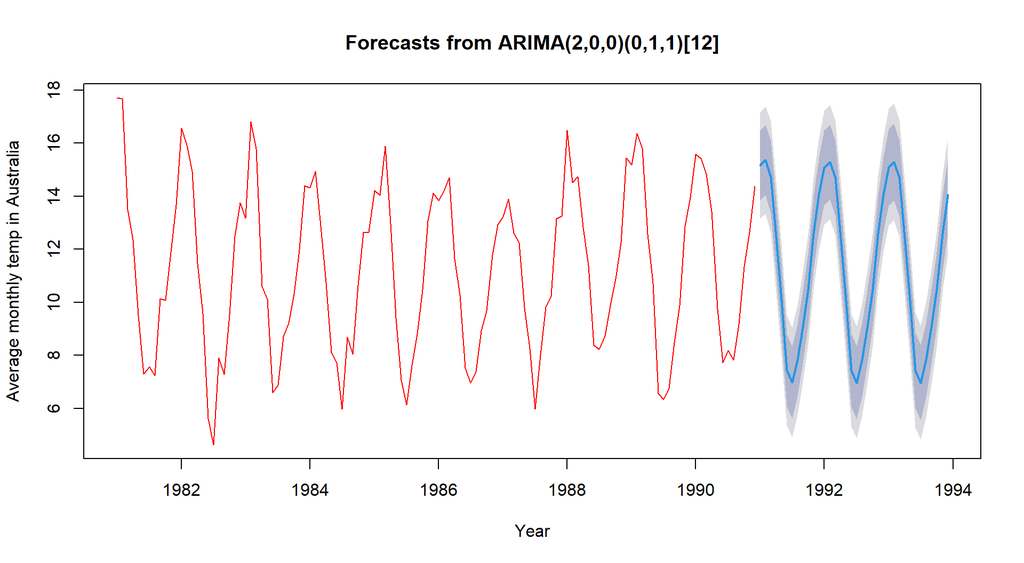

```
## ETS(A,N,A)
##
## Call:
##  ets(y = tSeries, lambda = LambdaOpt, biasadj = T)
##
##   Box-Cox transformation: lambda= 0.9708
##
##   Smoothing parameters:
##     alpha = 0.142
##     gamma = 1e-04
##
##   Initial states:
##     l = 9.7469
##     s = 2.5109 1.2192 -0.843 -2.0385 -3.0935 -4.3115
##            -3.6586 -1.1241 0.8743 3.229 3.8023 3.4335
##
##   sigma:  0.9022
##
##      AIC     AICc      BIC
## 564.9223 569.5377 606.7347
```

Residuals:

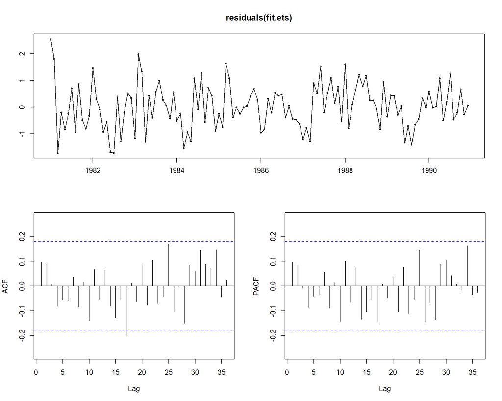

Ljung-Box test p-values for them:

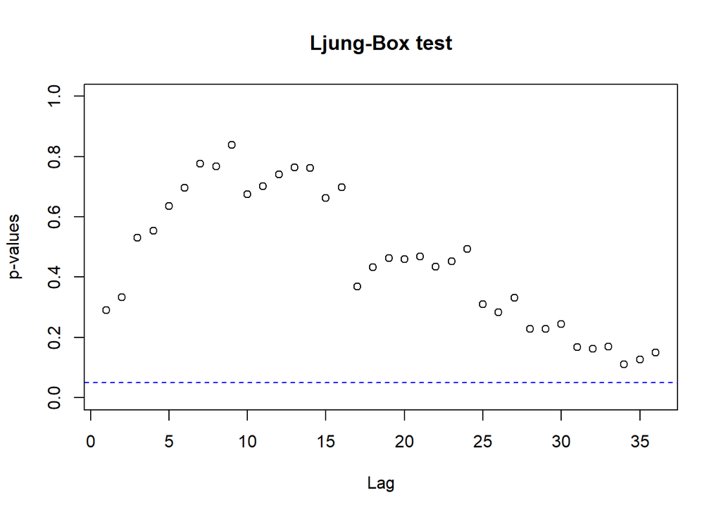

The residuals are not correlated

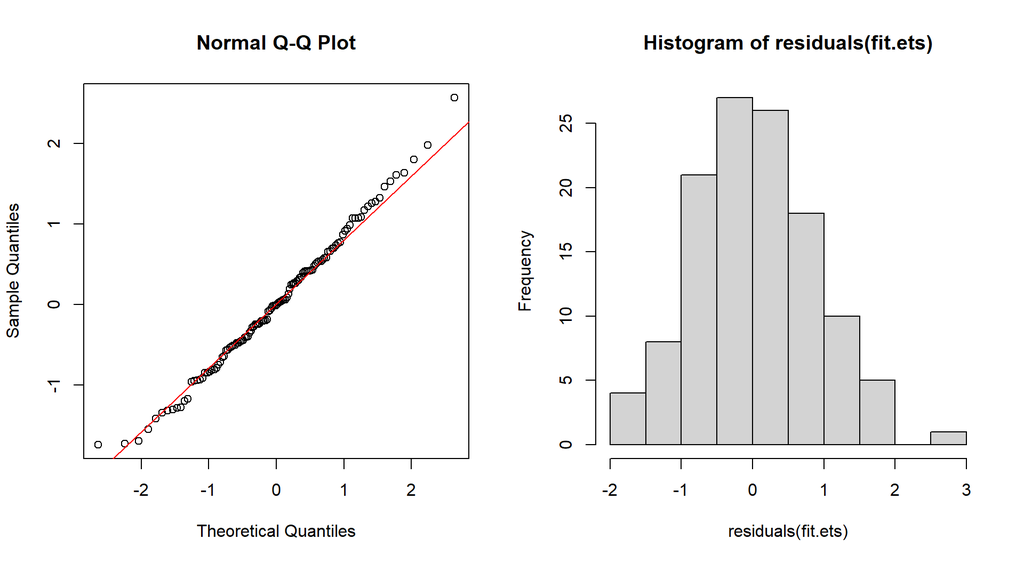

```r
shapiro.test(residuals(fit.ets))$p.value
```

```
## [1] 0.7770585
```

```r
wilcox.test(residuals(fit.ets))$p.value
```

```
## [1] 0.9113769
```

```r
kpss.test(residuals(fit.ets))$p.value
```

```
## [1] 0.1
```

Fitting the selected model to the first $T-D$ points of the series to check the accuracy of the forecast on the last $D$ points:

```
##                      ME      RMSE       MAE       MPE     MAPE      MASE
## Training set 0.02756745 0.9366154 0.7255991 -0.505295 6.865265 0.7095636
## Test set     0.67593550 1.0210663 0.8413688  5.576229 7.576279 0.8227749
##                   ACF1 Theil's U
## Training set 0.1692295        NA
## Test set     0.1070691 0.5890829
```

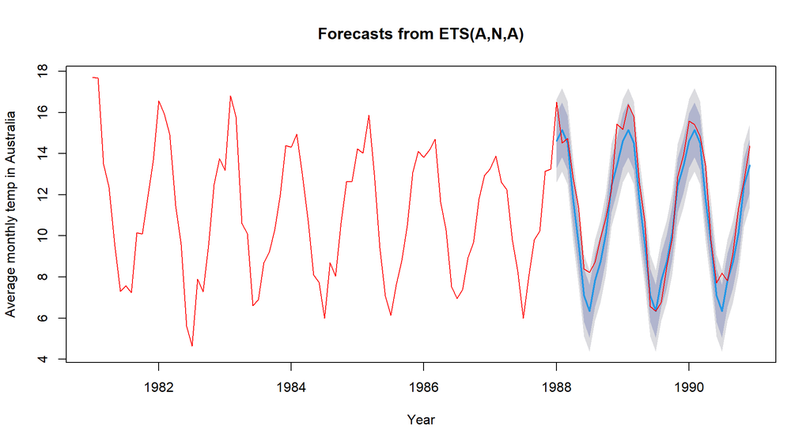

now the same with auto arima

```
##                      ME     RMSE       MAE       MPE     MAPE      MASE
## Training set -0.1321867 1.006827 0.7291781 -1.579189 7.187558 0.7130635
## Test set      0.7355364 1.168978 0.9444212  5.386015 8.140112 0.9235498
##                     ACF1 Theil's U
## Training set -0.02740573        NA
## Test set      0.18772066 0.6237839
```

and manual arima

```
##                     ME     RMSE       MAE      MPE     MAPE      MASE
## Training set 0.1522615 1.030012 0.7793628 1.248548 7.643854 0.7621391
## Test set     0.7300160 1.173449 0.9450290 5.308442 8.134703 0.9241442
##                    ACF1 Theil's U
## Training set 0.04133296        NA
## Test set     0.18785544 0.6229947
```

```
##
##  Diebold-Mariano Test
##
## data:  resres.auto
## DM = 0.5738, Forecast horizon = 1, Loss function power = 2, p-value =
## 0.5673
## alternative hypothesis: two.sided
```

Diebold-Mariano test does not find the differences between forecasting errors of two ARIMAs significant. The residuals of two models have the same properties. Auto model has a little smaller AICc, so we’ll use the auto tuned ARIMA.

Comparing the residuals of the best ARIMA and the best ETS models:

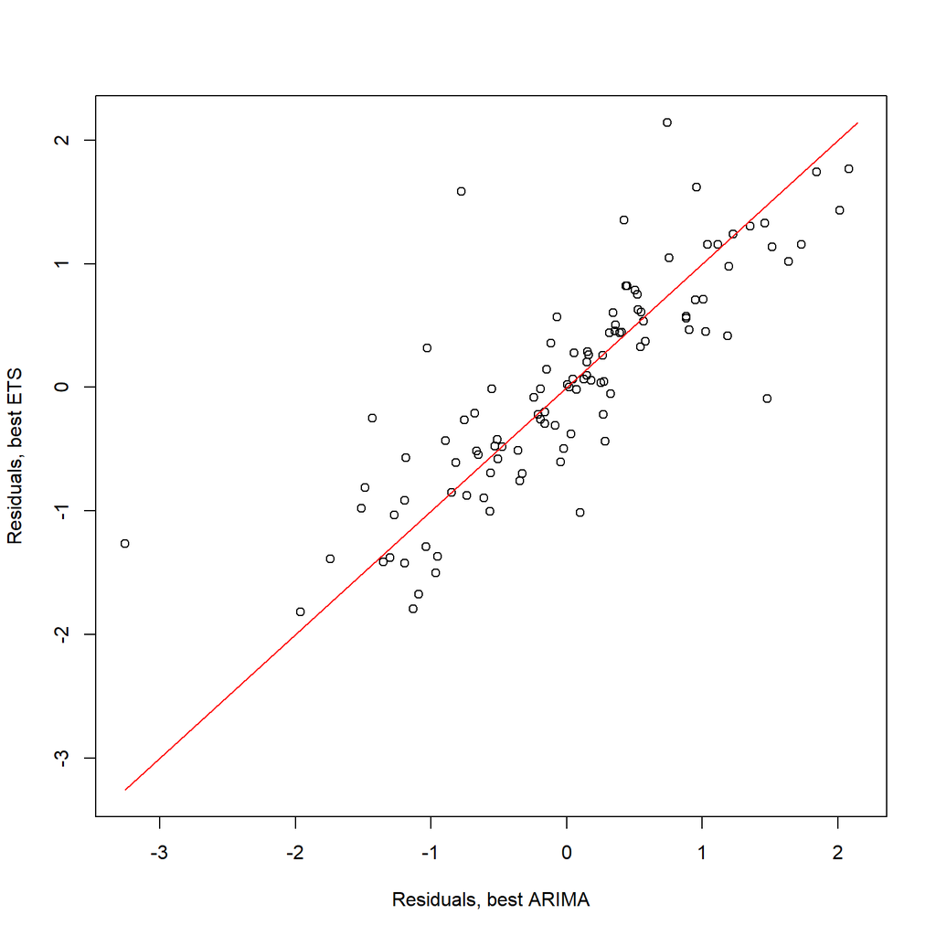

```
##
##  Diebold-Mariano Test
##
## data:  res.autores.ets
## DM = 0.99149, Forecast horizon = 1, Loss function power = 2, p-value =
## 0.3237
## alternative hypothesis: two.sided
```

p-value > 0.05, so they are not significantly different. the forecasts for auto arima and ets are above